# Introduction

This project presents a comprehensive analysis of sales data, focusing on various aspects to uncover valuable insights into product trends, customer behavior, and business performance. The analysis is segmented into several key areas, each designed to address specific business needs and provide actionable insights:

## Data Source

https://www.kaggle.com/datasets/subhendughosh/monthly-sales-data

## Key Research Questions

- What are the monthly revenue trends and seasonality patterns observed in the sales data?
- Which products are the top sellers, and how do they contribute to overall revenue?
- How is sales performance distributed across different cities?
- What is the relationship between product pricing and quantity ordered?
- What are the variations in sales performance across different cities and months?
- How does the sales trend of the most sold product vary over time
- What products are frequently purchased together, and how strong are these associations?

```python
# Import important modules
import pandas as pd
import numpy as np
import matplotlib.pyplot as plt
import seaborn as sns
import os
import mlxtend
```

```python
# List all files in the specified directory and store them in a list
files=[file for file in os.listdir('C:\\Users\\u1\\Downloads\\MonthlySalesData')]
for file in files:
    print(file)
```

```
Sales_April_2019.csv
Sales_August_2019.csv
Sales_December_2019.csv
Sales_February_2019.csv
Sales_January_2019.csv
Sales_July_2019.csv
Sales_June_2019.csv
Sales_March_2019.csv
Sales_May_2019.csv
Sales_November_2019.csv
Sales_October_2019.csv
Sales_September_2019.csv
```

```python
# Define the directory path containing CSV files, initialize an empty DataFrame,
# and concatenate data from each CSV file into the combined_data DataFrame.
path='C:\\Users\\u1\\Downloads\\MonthlySalesData'
combined_data=pd.DataFrame()

for file in files:
    df= pd.read_csv(path+"/"+file)
    combined_data=pd.concat([combined_data,df])

combined_data.shape
```

```
(186850, 6)
```

```python
 combined_data.to_csv('C:\\Users\\u1\\Downloads\\Telegram Desktop\\MonthlySales\\combined.csv', index=False)
```

```python
combined_data.head()
```

|  | Order ID | Product | Quantity Ordered | Price Each | Order Date | Purchase Address |
| --- | --- | --- | --- | --- | --- | --- |
| 0 | 176558 | USB-C Charging Cable | 2 | 11.95 | 04/19/19 08:46 | 917 1st St, Dallas, TX 75001 |
| 1 | NaN | NaN | NaN | NaN | NaN | NaN |
| 2 | 176559 | Bose SoundSport Headphones | 1 | 99.99 | 04/07/19 22:30 | 682 Chestnut St, Boston, MA 02215 |
| 3 | 176560 | Google Phone | 1 | 600 | 04/12/19 14:38 | 669 Spruce St, Los Angeles, CA 90001 |
| 4 | 176560 | Wired Headphones | 1 | 11.99 | 04/12/19 14:38 | 669 Spruce St, Los Angeles, CA 90001 |

```python
combined_data.isnull().sum()
```

```
Order ID            545
Product             545
Quantity Ordered    545
Price Each          545
Order Date          545
Purchase Address    545
dtype: int64
```

```python
#drop the rows with null value
combined_data = combined_data.dropna(how="all")
combined_data.isnull().sum()
```

```
Order ID            0
Product             0
Quantity Ordered    0
Price Each          0
Order Date          0
Purchase Address    0
dtype: int64
```

```python
# Check for duplicates
duplicates = combined_data.duplicated()
print(f'Total duplicates in the dataset: {duplicates.sum()}')
num_rows = combined_data.shape
print(f'The dataset has {num_rows} rows.')
```

```
Total duplicates in the dataset: 618
The dataset has (186305, 6) rows.
```

```python
# Remove duplicates
combined_data = combined_data.drop_duplicates()
num_rows = combined_data.shape
print(f'The dataset has {num_rows} rows.')
```

```
The dataset has (185687, 6) rows.
```

## 1.Monthly Revenue Distribution

```python
#add month column
combined_data['Order Date'][0]
```

```
0    04/19/19 08:46
0    08/31/19 22:21
0    12/30/19 00:01
0    02/18/19 01:35
0    01/22/19 21:25
0    07/26/19 16:51
0    06/23/19 19:34
0    03/28/19 20:59
0    05/16/19 17:14
0    11/21/19 09:54
0    10/28/19 10:56
0    09/17/19 14:44
Name: Order Date, dtype: object
```

```python
'19/04/19 08:46'.split(' ')[0]
```

```
'19/04/19'
```

```python
'2019-04-19 08:46:00'.split(' ')[0].split('-')[1] ## extracting month from "Order Date"
```

```
'04'
```

```python
def return_month(x):
    return x.split('/')[0]
```

```python
combined_data['Month'] = combined_data['Order Date'].apply(return_month) ## applying return_month function on top of "Order Date" feature
```

```python
print(combined_data['Order Date'].unique())
```

```
['04/19/19 08:46' '04/07/19 22:30' '04/12/19 14:38' ... '09/23/19 07:39'
 '09/19/19 17:30' '09/30/19 00:18']
```

```python
combined_data.dtypes
```

```
Order ID            object
Product             object
Quantity Ordered    object
Price Each          object
Order Date          object
Purchase Address    object
Month               object
dtype: object
```

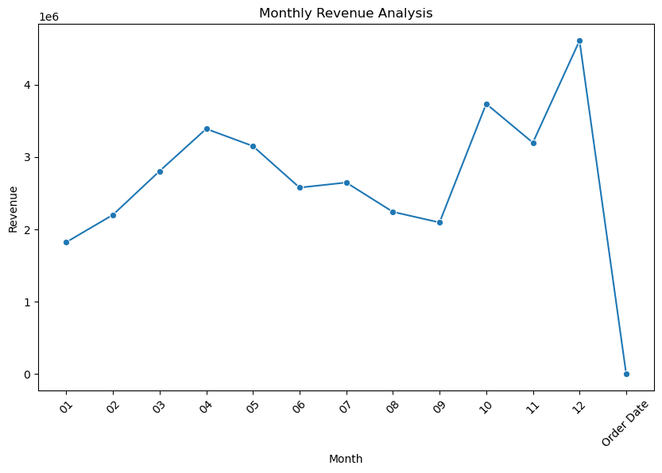

```python
# Convert 'quantity ordered' and 'price each' to numeric types
combined_data['Quantity Ordered'] = pd.to_numeric(combined_data['Quantity Ordered'], errors='coerce')
combined_data['Price Each'] = pd.to_numeric(combined_data['Price Each'], errors='coerce')

# Calculate total revenue
combined_data['Revenue'] = combined_data['Quantity Ordered'] * combined_data['Price Each']
monthly_revenue = combined_data.groupby('Month')['Revenue'].sum().reset_index()

# vizualize
plt.figure(figsize=(10, 6))
sns.lineplot(data=monthly_revenue, x='Month', y='Revenue', marker='o')
plt.title('Monthly Revenue Analysis')
plt.xticks(rotation=45)
plt.show()
```

- Sales typically dip in January and September, often due to post-holiday slumps and seasonal lulls.
- November's revenue is lower than October's, possibly due to a decrease in consumer spending between Halloween and the December holiday rush.
- December, October, and April respectively show peak revenue periods, driven by major shopping seasons and promotional events.